# Supervised learning, classification, cross validation, variable selection

Contributors: Gabriela Cohen Freue, W. Evan Durno, Jasleen Grewal

## Learning objectives

By the end of this tutorial, you should be able to  
- Filter gene expression data to remove uninformative features.  
- Further subselect a set of variables using a fixed information criteria, and know when it may not be required/possible to do so.  
- Understand the concept of held-out test set, training set, and validation set.  
- Select a suitable classifier (based on size of training dataset) and train a model with the input training data.  
- Get predicted labels for a validation set, from the trained classifier model.  
- Understand the utility of cross validation in selecting an optimal model  
- Be able to identify at what part of the supervised learning process CV should be used. - Explain how cross validation is different from bootstrapping.  
- Assess the best selected model’s performance on the held out test set.  
- Recognize why we can’t go back and reselect models after assessment on the held out test set.  
- Be able to distinguish between the following scenarios for using supervised machine learning, and enumerate metrics for assessing performance in each case:  
- 2 class classification problem  
- Multi-clas classification problem  
- Be able to define accuracy, precision, sensitivity, specificity, F1-score, Kappa score.  
- Replicate analysis in either MLInterface, GLMnet, CMA, or Caret (take home exercise, optional).

# Introduction

In this Seminar we go over packages and codes for performing supervised learning and evaluation in R. In supervised learning, one is given a training data set with known response and covariates and our goal is to predict the response in a new test set for which we only know the covariates. A supervised learning process can be decomposed into the following steps:

*Step 1*: Data preprocessing. Before getting started with feature selection and training, we must make sure we have adjusted the data to account for any batch effects or biases from outliers.

*Step 2*: Select Features. Before training a model, in many applications, it is usually important to perform a pre-filtering step in which one retains only the most informative features (e.g., genes) as candidate “biomarkers”. The amount of features retained to select and train a model is up to the analyst and the methods used in the next steps. For example, some methods may be unfeasible or too slow to run with a large number of features.

*Step 3*: Select and train a classifier. Once the set of candidate markers have been selected, the next step is to select and train a model to predict the labels of a test data. We will also tune the parameters for each classifier using cross-validation.

*Step 4*: Test. Finally, a model is chosen and used to predict labels of a test data.

## R packages

There are many packages for performing supervised learning in R, each of which may implement one or more algorithms. There have also been at least two major efforts to unify these libraries under a common framework to make them easier to use: `MLInterfaces` and `CMA`. Although these may be useful and save you a lot of time in your analysis, it is important that you understand what these packages are doing and what they are *not* doing. Thus, I will not use these packages in this Seminar but I encourage you to reproduce the analysis using at least one of them! (I recommend `CMA`).

Install the following packages from Bioconductor: `CMA` and `GEOquery`, and from CRAN: `ROCR`, `car`, `e1071` (for SVM), and `glmnet`.

```r
source('http://bioconductor.org/biocLite.R')
biocLite('GEOquery')
biocLite('CMA')

install.packages("ROCR")
```

```r
library(MASS)
library(reshape)
library(car)
library(limma)
library(e1071)
library(glmnet)
library(ROCR)
library(CMA)
library(lattice)
library(class)
library(RCurl)
options('download.file.method'='curl')
library(GEOquery)
```

## Data Set

This seminar is based on a dataset that comes from a paper by [Smeets et al. 2010](http://www.ncbi.nlm.nih.gov/geo/query/acc.cgi?acc=GSE23177), who studied Affymetrix expression profiles from primary breast tumors. Smeets group was interested in whether tumors which had spread to lymph nodes (LN positive, generally a bad sign) have different gene expression profiles than LN negative tumors. If so, a gene expression signature can be use to predict tumor class.

Their data set contains 24236 genes on 116 samples. The status of the lymph node is known for each sample, with 59 LN positive and 57 LN negative. Samples were divided into two parts: 96 samples (48 LN positive and 48 LN negative) were used as a “training” set and 20 samples (11 LN positive and 9 LN negative) were used as a “test” set. There is also a quantitative measure, “LnRatio”, the fraction of affected lymph nodes, presumably reflecting “how bad” the LnStatus is. Thus, we can use this dataset to illustrate classification and regularization methods! This seminar will focus on the first task, i.e., classification. In the past, Paul selected this dataset to illustrate the challenges of supervised learning tasks!

In the paper, the authors trained a support vector machine classifier to distinguish between LN positive and LN negative tumors (i.e., classification), and evaluated the results using ROC curves. After some optimization, they got an area under the ROC curve (AUC) of 0.66 on the training set and 0.65 on the test data. This is better than chance, but still not very convincing results about the relevance of the derived molecular signature (random chance would give an AUC of 0.5; perfect classification would give an AUC of 1.0).

### Data Preparation

First, let’s retrieve our datasets from GEO with `getGEO` from `GEOquery` package. Warning: this may take several minutes! So to avoid re-downloading in the future, save the data once you get it into a good shape.

```r
if(file.exists("class_LNstatus.Rdata")) { # if previously downloaded
  load("class_LNstatus.Rdata")
} else { # if downloading for the first time
  # takes a several mins!; returns a list
  datgeo <- getGEO('GSE23177', GSEMatrix = TRUE)
  dat <- datgeo[[1]]   #Note that dat is an ExpressionSets

  str(pData(dat), max.level = 0)

  # extract only those variables of interest
  pData(dat) <-
    subset(pData(dat),
           select = c("characteristics_ch1.2",
                      "characteristics_ch1.3","characteristics_ch1"))
  names(pData(dat))<-c("LnStatus", "LnRatio", "Set")

  #Note: LNRatio will not be used in this Seminar. However, you can use it to try some of the regularization techniques learned in class

  # split the ExpressionSet into training and test sets.
  train.es <- dat[, dat$Set == "patient type: training set"]
  test.es <- dat[ , dat$Set != "patient type: training set"]

  #Re-label factor
  pData(train.es)$LnStatus <-
      recode(pData(train.es)$LnStatus, "levels(pData(train.es)$LnStatus)[1]='neg'; else='pos'", levels = c('neg', 'pos'))

  pData(test.es)$LnStatus <-
      recode(pData(test.es)$LnStatus, "levels(pData(test.es)$LnStatus)[1]='neg'; else='pos'",
             levels = c('neg', 'pos'))

  # create data matrices with expression values (probesets in rows). Some of the functions we will use do not take ExpressionSets as objects
  trainDat <- exprs(train.es)
  testDat <- exprs(test.es)

  # Redefine the quantitative variable LnRatio to make it a numeric variable.
  ntrain <- dim(pData(train.es))[1]
  ntest <- dim(pData(test.es))[1]

  pData(train.es)$LnRatio <- as.numeric(unlist(strsplit(as.vector(unlist(pData(train.es)$LnRatio)), ":", fixed = TRUE))[(1:ntrain)*2])
  pData(test.es)$LnRatio <- as.numeric(unlist(strsplit(as.vector(unlist(pData(test.es)$LnRatio)), ":", fixed = TRUE))[(1:ntest)*2])

  # save the data to avoid future re-downloading
  save(dat,trainDat,testDat,train.es,test.es, file = "class_LNstatus.Rdata")
}
```

Now, we can do some exploratory analysis of the data before trying some classification methods.

```r
# undestand your data for classification
table(pData(train.es)$LnStatus)
```

```
##
## neg pos
##  48  48
```

```r
table(pData(test.es)$LnStatus)
```

```
##
## neg pos
##   9  11
```

```r
# understand the continuous response
tapply(pData(train.es)$LnRatio,pData(train.es)$LnStatus,summary)
```

```
## $neg
##    Min. 1st Qu.  Median    Mean 3rd Qu.    Max.
##       0       0       0       0       0       0
##
## $pos
##    Min. 1st Qu.  Median    Mean 3rd Qu.    Max.
##  0.0400  0.0700  0.1100  0.1935  0.2275  0.9600
```

```r
tapply(pData(test.es)$LnRatio,pData(test.es)$LnStatus,summary)
```

```
## $neg
##    Min. 1st Qu.  Median    Mean 3rd Qu.    Max.
##       0       0       0       0       0       0
##
## $pos
##    Min. 1st Qu.  Median    Mean 3rd Qu.    Max.
##  0.0500  0.1800  0.5000  0.4573  0.6100  0.9400
```

```r
# look at the expression of 3 randomly picked genes in both training and test sets
set.seed(1234)
(getMe <- sample(1:nrow(train.es), size = 3)) ## [1]   2756 15082 14766
```

```
## [1]  2756 15082 14766
```

```r
# training data
trDat <- trainDat[getMe, ]
str(trDat)
```

```
##  num [1:3, 1:96] 7.19 9.17 8.38 7.13 9.38 ...
##  - attr(*, "dimnames")=List of 2
##   ..$ : chr [1:3] "201513_at" "223139_s_at" "222698_s_at"
##   ..$ : chr [1:96] "GSM570518" "GSM570519" "GSM570520" "GSM570521" ...
```

```r
trDat <- data.frame(LnStatus=pData(train.es)$LnStatus, Set=rep("train",nrow(pData(train.es))),t(trDat))
str(trDat)
```

```
## 'data.frame':    96 obs. of  5 variables:
##  $ LnStatus    : Factor w/ 2 levels "neg","pos": 1 1 2 1 1 2 1 1 2 1 ...
##  $ Set         : Factor w/ 1 level "train": 1 1 1 1 1 1 1 1 1 1 ...
##  $ X201513_at  : num  7.19 7.13 7.39 6.86 6.96 ...
##  $ X223139_s_at: num  9.17 9.38 9.03 9.55 9.5 ...
##  $ X222698_s_at: num  8.38 8.24 7.23 7.87 8.45 ...
```

```r
plotDat.train <- melt(trDat, id=c("LnStatus","Set"),variable_name="gene")
colnames(plotDat.train)[colnames(plotDat.train)=="value"]="gExp"

# test data
tDat <- testDat[getMe, ]
str(tDat)
```

```
##  num [1:3, 1:20] 6.05 9.15 7.55 6.87 8.95 ...
##  - attr(*, "dimnames")=List of 2
##   ..$ : chr [1:3] "201513_at" "223139_s_at" "222698_s_at"
##   ..$ : chr [1:20] "GSM570498" "GSM570499" "GSM570500" "GSM570501" ...
```

```r
tDat <- data.frame(LnStatus=pData(test.es)$LnStatus,Set=rep("test",nrow(pData(test.es))), t(tDat))
str(tDat)
```

```
## 'data.frame':    20 obs. of  5 variables:
##  $ LnStatus    : Factor w/ 2 levels "neg","pos": 1 1 1 1 1 1 1 1 1 2 ...
##  $ Set         : Factor w/ 1 level "test": 1 1 1 1 1 1 1 1 1 1 ...
##  $ X201513_at  : num  6.05 6.87 6.71 8 6.54 ...
##  $ X223139_s_at: num  9.15 8.95 9.09 9.81 9.2 ...
##  $ X222698_s_at: num  7.55 8.34 8.32 7.33 8.14 ...
```

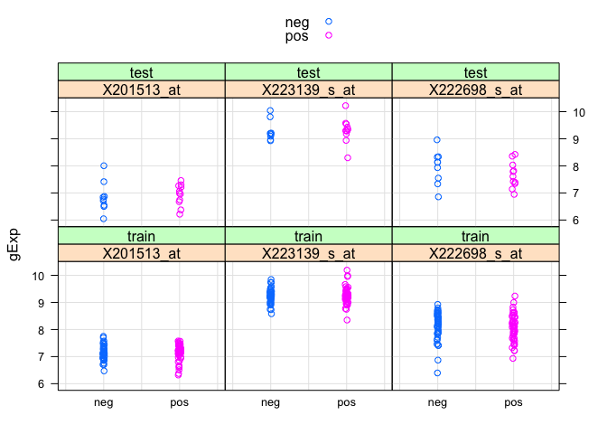

```r
plotDat.test <- melt(tDat, id=c("LnStatus","Set"),variable_name="gene")
colnames(plotDat.test)[colnames(plotDat.test)=="value"]="gExp"

plotDat <- rbind(plotDat.train,plotDat.test)

# plot 3 randomly picked genes in both training and test sets
stripplot(gExp ~ LnStatus | gene+Set, plotDat,
                       grid = TRUE,
                       group = LnStatus, auto.key = TRUE,
                       jitter.data = TRUE)
```

# Classification

The prediction of a discrete response is usually refer to as *classification*. A response taking values over a finite set of labels is essentially the same thing as a factor. We will use the dataset from Smeets et al. to find the *best-trained* classifier and use it to predict the `LnStatus` of the 20 samples in the test set, i.e., classify those as “lymph node positive” or “negative”.

## Data preprocessing

We should check to ensure there are no missing values in our data.

```r
sum(is.na(trainDat))
```

```
## [1] 0
```

```r
sum(is.na(testDat))
```

```
## [1] 0
```

Here we see there are no missing values in our dataset, so we don’t have to worry about that.

Other pre-processing operations that can be done are:  
- centering, scaling, normalizing  
- imputing missing data  
- transforming individual features (like boolean measurements)

When you are working with expression data, you may also need to use some normalization methods to ensure your variables are comparable across all your samples. For example, when working with count data, it is advised to log transformed and quantile-normalize your data, so that your samples have similar distributions.

## Feature and Model Selection

We will now identify the best set of features that we will use to train the model using a cross-validation. Thus, I will divide the training set into 6 folds (the authors used 10 folds). We also want the proportion of positive and negative examples in each split to be approximately the same as for the full data set (i.e., stratified 6-fold CV with 8 positive and 8 negative samples within each fold). For each round of cross-validation, we use one fold as the test data and the rest of the data as training to select features and train different classifier.

### Cross-validation

Although it makes sense to proceed as described above, many methods are available and many constants within methods need to be selected in these steps. Thus, a *cross-validation* is usually required to *evaluate* how well different trained models work and select the *best* model to proceed. Note that although you may only want to select among different choices available in Step 2, the cross-validation needs to start in Step 1. Why? The results of the cross-validation will be over-optimistic and biased if the samples in the test sets of the cross-validation (i.e., left-out folds) were used to *select* the most promising features in Step 1!! For example, if the performance of a complex model is (artificially) good, you may not penalize regression coefficients enough in Step 2, and may yield to a poor performance in Step 3.

In many studies, in the absence of a test set, cross-validation is used to estimate performance. In those cases, a *nested cross-validation* is required! The inner cross-validation will be used to select features and tune parameters, the outer cross-validation will be used to a selected test model.

In this seminar, we will work with a dataset that has both a training and a test set. Thus, we will not do a nested cross-validation. However, keep it in mind for your project or future work!

#### Making cross validation splits

This is not the only way to create splits of the training data to run a cross-validation. Note that if the samples can not be evenly divided into the nfolds you specified, then you need to complete the matrices below with NAs and call for entries different from NA at those folds.

```r
nfold <- 6

tabTrain <- table(train.es$LnStatus)

indlist <- sapply(names(tabTrain), function(z) which(train.es$LnStatus == z), simplify = FALSE)

set.seed(1234)

#Each row contains 8 pos and 8 negative samples.

fold.pos <- matrix(sample(indlist[["pos"]]),nrow=nfold)
fold.neg <- matrix(sample(indlist[["neg"]]),nrow=nfold)
```

*Note*: with `CMA` you can use the command `GenerateLearningsets` to split the training data into folds. However, it does not show you how the data was split. Thus, you either use CMA for all or you write your own script.

```r
splits <- GenerateLearningsets(y = train.es$LnStatus, method="CV", fold=6, strat= TRUE)
```

### Loop for feature selection and modeling

To illustrate how to select a model, I will use the top-50 genes selected by `limma` (within each fold). Note that this number is very arbitrary and other options may make more sense like using a p-value threshold or testing different options with this CV. For this example, I’m using only the top-50 genes as methods like LDA and Logit can not be run on more features than samples. However, other methods like kNN or SVM will do well with more features.

In this example, I will compare 7 different models: kNN for k={1,5,10,15}, LDA, Logit, SVM. Feel free to add other methods to the list!

```r
#Define here the constants that you will not evaluate. For example, I will use the top-50 limma genes

ngenes <- 50
nmethod <- 7 #number of methods you plan to compare.

#Define here an output objects to store results
pr.err <- matrix(-1, nfold,nmethod, dimnames=list(paste0("Fold",1:nfold),c("1NN","5NN","10NN", "15NN","LDA","Logit","SVM")))

for(i in 1:nfold){

  #Test Fold for the i-th step
  testdat.fold<-trainDat[,c(fold.pos[i,],fold.neg[i,])]
  #I will create a factor of classes for the test set of the i_th fold
  testclass.fold<-train.es$LnStatus[c(fold.pos[i,],fold.neg[i,])]


  #The rest of the samples are the training set for the i-th step
  traindat.fold<-trainDat[,-c(fold.pos[i,],fold.neg[i,])]
  trainclass.fold<-train.es$LnStatus[-c(fold.pos[i,],fold.neg[i,])]

  #Step 1: feature selection (do you remember limma?).

  # Note that a different set of genes will be selected for each fold! you can then compare how consistent these sets were.

  limma.dat<-as.data.frame(traindat.fold)
  desMat <- model.matrix(~ trainclass.fold, limma.dat) #design matrix
  trainFit <- lmFit(limma.dat, desMat)
  eBtrainFit <- eBayes(trainFit)

  # top-50 limma genes
  top.fold <- topTable(eBtrainFit, coef = which(colnames(coef(trainFit)) != "(Intercept)"),
                       n = ngenes,sort.by="P")

  #Retain the top-50 limma genes from the train and test sets
  traindat.fold <- traindat.fold[rownames(top.fold),]
  testdat.fold <-  testdat.fold[rownames(top.fold),]


  #STEP 2: select a classifier
  #Set a counter for the method tested
  l <- 0

  #kNN classifiers
  for(kk in c(1,5,10,15)) {
    #every time you get inside this loop, the l counter gets redefined (i.e., 1, 2, etc for         method 1, method 2, etc)
    l <- l+1

    #knn needs samples in rows
    yhat.knn <- knn(train=t(traindat.fold), test=t(testdat.fold), cl=trainclass.fold,
                    k = kk)
    #Store the prediction error for each kk within this fold
    pr.err[i,l]<- mean(testclass.fold != yhat.knn)
                          } #end of kNN loop

  #LDA method. Note that you can change the prior parameter to reflect a different proportion of case and control samples. The default is to use the class proportions from the training set.

  m.lda <- lda(x=t(traindat.fold), group=trainclass.fold, prior=c(.5, .5))
  yhat.lda <- predict(m.lda, newdata=t(testdat.fold))$class
  pr.err[i,"LDA"] <-mean(testclass.fold != yhat.lda)

  #Logit
  glm.dat <- data.frame(t(traindat.fold), group=trainclass.fold)

  # 50 factors still will cause optimization warnings
  # Try without warning suppression to see
  # To further reduce parameters, regularized regression can be used
  # To use regularized regression uncomment lines followed by "uncomment for regularized regression"
  suppressWarnings( m.log <- glm(group ~ ., data=glm.dat,family=binomial) )

  # uncomment for regularized regression
  # m.log <- glmnet( t(traindat.fold) , trainclass.fold ,family="binomial")

  pr.log <- predict(m.log,newdata=data.frame(t(testdat.fold)),type="response")

  # uncomment for regularized regression
  # pr.log <- predict(m.log,newdata=data.frame(t(testdat.fold)),type="response",newx=t(testdat.fold))

  pr.cl <- rep(0,length(testclass.fold))
  pr.cl[pr.log > 1/2] <- "pos"
  pr.cl[pr.log <= 1/2] <- "neg"

  pr.cl <- factor(pr.cl)
  pr.err[i,"Logit"] <- mean( pr.cl != testclass.fold )

  #SVM
  m.svm <- svm(x=t(traindat.fold), y=trainclass.fold, cost=1, type="C-classification",
               kernel="linear")
  pr.svm <- predict(m.svm,newdata=t(testdat.fold))

  pr.err[i,"SVM"] <- mean( pr.svm != testclass.fold )
  } #end of CV loop
```

### Error Rates

Now you can get the average prediction error for all methods. Note that the prediction errors are high! not too much hope for the real test run!

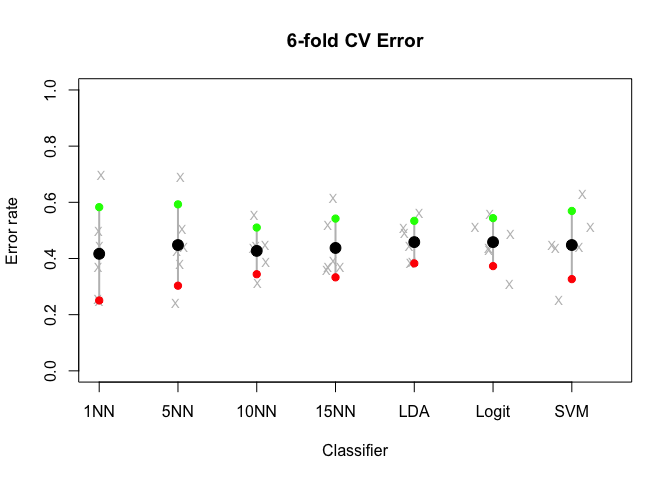

```r
cv.err <- colMeans(pr.err)

# mean - 1 sd (sd of the 6 error rates)
ls <- cv.err - apply(pr.err, 2, sd)

# mean + 1 sd (sd of the 6 error rates)
us <- cv.err + apply(pr.err, 2, sd)

# plot the results
plot(1:nmethod, cv.err, ylim=c(0, 1), xlim=c(1, (nmethod+.5)),type='n',
axes=FALSE, xlab='Classifier', ylab='Error rate',main="6-fold CV Error")

for(j in 1:ncol(pr.err))
   points(jitter(rep(j, 6), factor=2), jitter(pr.err[,j]), cex=0.8, pch='X', col='gray')

for(i in 1:nmethod)
   lines(c(i, i), c(ls[i], us[i]), lwd=2, col='gray')
points(1:nmethod, ls, pch=19, col='red')
points(1:nmethod, us, pch=19, col='green')
points(1:nmethod, cv.err, pch=19, cex=1.5, col='black')
axis(2, ylab='Error rate')
axis(1, 1:nmethod, colnames(pr.err))

box()
```

### Results of the CV

**Exercise 1**: perform 100 runs of this CV before selecting a model to test! Add at least one rule to select the list of models, e.g., use genes with a p-val threshold < cutoff.

**Exercise 2**: Use AUC as a criteria to select a model based on the training data! Tip: extract the predicted probabilities from each method and use the roc function in ROCR.

## Testing the selected model

Now that we decided on which method we are going to use to classify samples in the test set, we need to train the model using the *FULL* training set and then classify samples of the test set. I will use the 10NN model.

```r
yhat.knn <- knn(train=t(trainDat), test=t(testDat), cl=train.es$LnStatus,
                     k = 10)
#Store the prediction error for each kk within this fold
pr.errTest<- mean(test.es$LnStatus != yhat.knn)
pr.errTest
```

```
## [1] 0.45
```

What does the prediction error mean?  
In this instance, we have evaluated how often the prediction matched the actual lymph node status, against the total number of cases. This is the **accuracy** metric.

Not good! In real practice, you should not keep trying until we get a good result! In fact, you must use cross-validation on the training dataset to evaluate different parameters and classifiers, and only evaluate the generalizability of the *best* model on the test set.  
However, in this seminar, I encourage you to try different options **as an exercise** and to see how much the results can change.

## CMA

Many steps of the CV defined above can be easily done with CMA. For example, Step 1 in the loop above can also be done using ‘CMA’ with the function ‘GeneSelection’, which selects the most informative features (e.g., gene) to build a classifier within each of the splits generated by ‘GenerateLearningsets’. Some learning algorithms do better if you only give them “useful” features.

```r
featureScores<-GeneSelection(X=t(trainDat), y=train.es$LnStatus, learningsets=splits, method="limma")
```

```
## GeneSelection: iteration 1
## GeneSelection: iteration 2
## GeneSelection: iteration 3
## GeneSelection: iteration 4
## GeneSelection: iteration 5
## GeneSelection: iteration 6
```

```r
#Compare list of selected genes using:
toplist(featureScores)
```

```
## top  10  genes for iteration  1
##
##    index importance
## 1   9265   25.37579
## 2   6936   24.85400
## 3  21592   24.55555
## 4   1702   23.99424
## 5  21919   23.98643
## 6  19932   21.29348
## 7   6938   20.60153
## 8  22524   20.18380
## 9  17847   18.77700
## 10  6937   18.74738
```

```r
#We can aggregate the results across the 6 splits.

seliter<-numeric()
for(i in 1:nfold) seliter<-c(seliter, toplist(featureScores, iter=i, top = 10, show=FALSE)$index)
(sort(table(seliter), dec=T)) # summarize
```

```
## seliter
##  1702  9265  6936 21919   808  6938 18958 19932 20571 21592 23206 23567
##     6     5     3     3     2     2     2     2     2     2     2     2
##    18   377   767  2690  3386  6937  7182  7183  8447 10254 10292 13581
##     1     1     1     1     1     1     1     1     1     1     1     1
## 13620 13802 15997 16094 16165 17847 18668 19152 19265 19402 19526 19577
##     1     1     1     1     1     1     1     1     1     1     1     1
## 21533 22524 22943
##     1     1     1
```

```r
# Choose the 20 probes which are chosen most commonly in the 6 splits
bestprobes<-as.numeric(names(sort(table(seliter), dec=T)))[1:20]

# examine the annotations. I just selected a few columns from the fData of the eSet.
(fData(dat)[bestprobes,c("Gene Symbol", "Gene Title", "ENTREZ_GENE_ID", "Representative Public ID" )])
```

```
##                                         Gene Symbol
## 1569472_s_at                        TTC3 /// TTC3P1
## 212384_at    ATP6V1G2-DDX39B /// DDX39B /// SNORD84
## 208661_s_at                         TTC3 /// TTC3P1
## 237746_at
## 1556088_at                                    RPAIN
## 208663_s_at                         TTC3 /// TTC3P1
## 228510_at                                     ATAT1
## 230609_at                                    CLINT1
## 232740_at                                MCM3AP-AS1
## 236196_at                                    ZNF326
## 242562_at
## 243751_at                                      CHD2
## 1552283_s_at                   ZDHHC11 /// ZDHHC11B
## 1554182_at                        TRIM73 /// TRIM74
## 1555920_at                                     CBX3
## 201440_at                                     DDX23
## 202182_at                                     KAT2A
## 208662_s_at                         TTC3 /// TTC3P1
## 208920_at                                       SRI
## 208921_s_at                                     SRI
##                                                                                                                                  Gene Title
## 1569472_s_at                                           tetratricopeptide repeat domain 3 /// tetratricopeptide repeat domain 3 pseudogene 1
## 212384_at    ATP6V1G2-DDX39B readthrough (NMD candidate) /// DEAD (Asp-Glu-Ala-Asp) box polypeptide 39B /// small nucleolar RNA, C/D box 84
## 208661_s_at                                            tetratricopeptide repeat domain 3 /// tetratricopeptide repeat domain 3 pseudogene 1
## 237746_at
## 1556088_at                                                                                                          RPA interacting protein
## 208663_s_at                                            tetratricopeptide repeat domain 3 /// tetratricopeptide repeat domain 3 pseudogene 1
## 228510_at                                                                                                 alpha tubulin acetyltransferase 1
## 230609_at                                                                                                             clathrin interactor 1
## 232740_at                                                                                                            MCM3AP antisense RNA 1
## 236196_at                                                                                                           zinc finger protein 326
## 242562_at
## 243751_at                                                                                       chromodomain helicase DNA binding protein 2
## 1552283_s_at                                                 zinc finger, DHHC-type containing 11 /// zinc finger, DHHC-type containing 11B
## 1554182_at                                                                tripartite motif containing 73 /// tripartite motif containing 74
## 1555920_at                                                                                                              chromobox homolog 3
## 201440_at                                                                                         DEAD (Asp-Glu-Ala-Asp) box polypeptide 23
## 202182_at                                                                                                    K(lysine) acetyltransferase 2A
## 208662_s_at                                            tetratricopeptide repeat domain 3 /// tetratricopeptide repeat domain 3 pseudogene 1
```

[output cut: 8 more lines]

```
## 208663_s_at                7267 /// 286495                 AI652848
## 228510_at                            79969                 AL566825
## 230609_at                             9685                 BF510429
## 232740_at                           114044                 BC002458
## 236196_at                           284695                 BF939032
## 242562_at                                                  AW772288
## 243751_at                             1106                 AA709148
## 1552283_s_at              79844 /// 653082                NM_024786
## 1554182_at               375593 /// 378108                 BC033871
## 1555920_at                           11335                 BU683892
## 201440_at                             9416                NM_004818
## 202182_at                             2648                NM_021078
## 208662_s_at                7267 /// 286495                 AI885338
## 208920_at                             6717                 AV752215
## 208921_s_at                           6717                   L12387
```

This looks promising since I get TTC3 and at least a couple of other genes that show up on Table 3 of the paper.

Similarly, you can use CMA to train and test a classifier within each CV fold (learningsets). However, there are things you can not do within CMA or that CMA is not doing right. For example, CMA can not do a full nested cross-validation. Additionally, it is not trivial to train the selected in the full dataset and then test it in the test set. CMA is more designed for CV. Thus, it is good to know how to do this things by hand as well.

Paul solved this problem in the following way: he made a `learningsets` object that has just one “split” defined by the samples in the training set.

```r
m<-matrix(which(dat$Set=="patient type: training set"), 1)

full.learningset<-new("learningsets", learnmatrix=m, method="my own", ntrain=96, iter=1)

fullFeatureScores<-GeneSelection(X=t(exprs(dat)), learningsets= full.learningset, y=dat$LnStatus, method="t.test")
```

```
## GeneSelection: iteration 1
```

```r
testclassif<-classification(X=t(exprs(dat)), y=dat$LnStatus, learningsets= full.learningset, genesel=fullFeatureScores, nbgene = 100, classifier =pknnCMA, k=5)
```

```
## iteration 1
```

```r
#Evaluation:
tres<-testclassif[[1]]
ftable(tres)
```

```
## number of missclassifications:  11
## missclassification rate:  0.55
## sensitivity: 0.545
## specificity: 0.333
##     predicted
## true 0 1
##    0 3 6
##    1 5 6
```

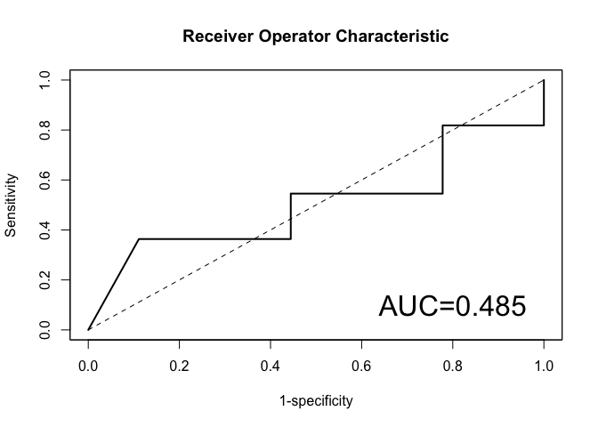

```r
roc(tres)
```

Note: his optimized classifier did terribly as well.

## Multiclass learning

You won’t always have a binary learning problem, where you are classifying a sample into 1 of 2 classes. Sometimes we might want to train a classifier a classifier with more than two classes.  
Here we will use the *caret* and *mlbench* packages for classification on a multi-class problem.

```r
library(caret)
library(mlbench)
```

We will be using the Soybean dataset, where our prediction is for the different problems associated with soybean crops. Our dataset has 683 samples, and 35 features being measured for each sample.  
Our categories are 19.

```r
cv_folds <- trainControl(method="cv", number=5)
data(Soybean)
unique(Soybean$Class)
```

```
##  [1] diaporthe-stem-canker       charcoal-rot
##  [3] rhizoctonia-root-rot        phytophthora-rot
##  [5] brown-stem-rot              powdery-mildew
##  [7] downy-mildew                brown-spot
##  [9] bacterial-blight            bacterial-pustule
## [11] purple-seed-stain           anthracnose
## [13] phyllosticta-leaf-spot      alternarialeaf-spot
## [15] frog-eye-leaf-spot          diaporthe-pod-&-stem-blight
## [17] cyst-nematode               2-4-d-injury
## [19] herbicide-injury
## 19 Levels: 2-4-d-injury alternarialeaf-spot ... rhizoctonia-root-rot
```

```r
summary(Soybean)
```

```
##                  Class          date     plant.stand  precip      temp
##  brown-spot         : 92   5      :149   0   :354    0   : 74   0   : 80
##  alternarialeaf-spot: 91   4      :131   1   :293    1   :112   1   :374
##  frog-eye-leaf-spot : 91   3      :118   NA's: 36    2   :459   2   :199
##  phytophthora-rot   : 88   2      : 93               NA's: 38   NA's: 30
##  anthracnose        : 44   6      : 90
##  brown-stem-rot     : 44   (Other):101
##  (Other)            :233   NA's   :  1
##    hail     crop.hist  area.dam    sever     seed.tmt     germ
##  0   :435   0   : 65   0   :123   0   :195   0   :305   0   :165
##  1   :127   1   :165   1   :227   1   :322   1   :222   1   :213
##  NA's:121   2   :219   2   :145   2   : 45   2   : 35   2   :193
##             3   :218   3   :187   NA's:121   NA's:121   NA's:112
##             NA's: 16   NA's:  1
##
##
##  plant.growth leaves  leaf.halo  leaf.marg  leaf.size  leaf.shread
##  0   :441     0: 77   0   :221   0   :357   0   : 51   0   :487
##  1   :226     1:606   1   : 36   1   : 21   1   :327   1   : 96
##  NA's: 16             2   :342   2   :221   2   :221   NA's:100
##                       NA's: 84   NA's: 84   NA's: 84
##
##
##
##  leaf.malf  leaf.mild    stem     lodging    stem.cankers canker.lesion
##  0   :554   0   :535   0   :296   0   :520   0   :379     0   :320
##  1   : 45   1   : 20   1   :371   1   : 42   1   : 39     1   : 83
##  NA's: 84   2   : 20   NA's: 16   NA's:121   2   : 36     2   :177
##             NA's:108                         3   :191     3   : 65
##                                              NA's: 38     NA's: 38
##
##
##  fruiting.bodies ext.decay  mycelium   int.discolor sclerotia  fruit.pods
##  0   :473        0   :497   0   :639   0   :581     0   :625   0   :407
##  1   :104        1   :135   1   :  6   1   : 44     1   : 20   1   :130
##  NA's:106        2   : 13   NA's: 38   2   : 20     NA's: 38   2   : 14
##                  NA's: 38              NA's: 38                3   : 48
##                                                                NA's: 84
##
##
##  fruit.spots   seed     mold.growth seed.discolor seed.size  shriveling
##  0   :345    0   :476   0   :524    0   :513      0   :532   0   :539
##  1   : 75    1   :115   1   : 67    1   : 64      1   : 59   1   : 38
##  2   : 57    NA's: 92   NA's: 92    NA's:106      NA's: 92   NA's:106
##  4   :100
##  NA's:106
##
##
##   roots
##  0   :551
##  1   : 86
##  2   : 15
##  NA's: 31
##
##
##
```

Let us pre-process our data.

```r
#Remove rows (samples) with missing values
soybean_x = Soybean[rowSums(is.na(Soybean)) == 0,]
#Then remove columns (features) with missing values
soybean_x = soybean_x[,colSums(is.na(soybean_x)) == 0]
dim(soybean_x)
```

```
## [1] 562  36
```

We are left with 562 samples and 35 attributes. The first column, `Class`, describes the categories. We will refactor this column since we have removed certain columns (and possibly some of the 19 classes)

```r
soybean_x$Class = (as.factor(as.character(soybean_x$Class)))
unique(soybean_x$Class)
```

```
##  [1] diaporthe-stem-canker  charcoal-rot           rhizoctonia-root-rot
##  [4] phytophthora-rot       brown-stem-rot         powdery-mildew
##  [7] downy-mildew           brown-spot             bacterial-blight
## [10] bacterial-pustule      purple-seed-stain      anthracnose
## [13] phyllosticta-leaf-spot alternarialeaf-spot    frog-eye-leaf-spot
## 15 Levels: alternarialeaf-spot anthracnose ... rhizoctonia-root-rot
```

Now we have 15 classes!

In this instance, we don’t have an external test set for evaluation, so we will be assessing the performance on a held-out test set. First, we create the held-out test set.  
*Note* that we are holding out this test set from our training data, and then performing data-splitting for validation within our training subset. In practise, like we did earlier, you would want to loop this multiple times with holding out a test set and training on the remainder dataset (using cross validation or bootstrapping to estimate your model accuracy on the test set).

```r
trainIndex <- createDataPartition(soybean_x$Class, p = .8,  list = FALSE,  times = 1)
soyTrain <- soybean_x[ trainIndex,]
soyTest  <- soybean_x[-trainIndex,]
```

**Cross validation results**  
We set up our cross-validation folds. Note we can also choose the option ‘cv’ or ‘LOOCV’ instead of ‘repeatedcv’.  
With ‘repeatedcv’, we don’t have to manually set up the multiple loops we did when we were using CMA.

```r
#Prepare resamling method for Cross-Validation folds
set.seed(7)
cv_control = trainControl(method="repeatedcv", number=5, repeats=10, classProbs=FALSE) #summaryFunction=mnLogLoss)
modelSvm_cv <- train(Class~., data=soyTrain, method="svmRadial", metric="accuracy", trControl=cv_control, verbose=FALSE)
```

[output not shown]

[output cut: 246 more lines]

[output not shown]

```r
# display results
print(modelSvm_cv)
```

```
## Support Vector Machines with Radial Basis Function Kernel
##
## 452 samples
##  35 predictor
##  15 classes: 'alternarialeaf-spot', 'anthracnose', 'bacterial-blight', 'bacterial-pustule', 'brown-spot', 'brown-stem-rot', 'charcoal-rot', 'diaporthe-stem-canker', 'downy-mildew', 'frog-eye-leaf-spot', 'phyllosticta-leaf-spot', 'phytophthora-rot', 'powdery-mildew', 'purple-seed-stain', 'rhizocto…
##
## No pre-processing
## Resampling: Cross-Validated (5 fold, repeated 10 times)
## Summary of sample sizes: 363, 363, 362, 359, 361, 361, ...
## Resampling results across tuning parameters:
##
##   C     Accuracy   Kappa
##   0.25  0.7115090  0.6699955
##   0.50  0.8835917  0.8692267
##   1.00  0.9215239  0.9121989
##
## Tuning parameter 'sigma' was held constant at a value of 0.06545455
## Accuracy was used to select the optimal model using  the largest value.
## The final values used for the model were sigma = 0.06545455 and C = 1.
```

```r
y_pred_cv = predict(modelSvm_cv, soyTest[,2:36])
```

When fitting this model with SVM, you might get the following request: ‘1 package is needed for this model and is not installed. (kernlab). Would you like to try to install it now?’. Enter *yes*.

We can also use bootstrap re-sampling instead of cross-validation folds. This means we take random samples from the dataset (with re-selection), against which to evaluate our model. This gives us an idea about hte variance of the model itself.

Bootstrapping is different from cross validation in that the latter splits the entire dataset into folds *without re-selection*.It is a robust method to estimate the accuracy of our model.

**Bootstrapped results**

```r
#Prepare resamling method for Bootstrapping
set.seed(7)
cv_control = trainControl(method="boot", number=100, classProbs=FALSE)
modelSvm_boot <- train(Class~., data=soyTrain, method="svmRadial", metric="accuracy", trControl=cv_control, verbose=FALSE)
```

[output not shown]

[output cut: 546 more lines]

[output not shown]

```r
# display results
print(modelSvm_boot)
```

```
## Support Vector Machines with Radial Basis Function Kernel
##
## 452 samples
##  35 predictor
##  15 classes: 'alternarialeaf-spot', 'anthracnose', 'bacterial-blight', 'bacterial-pustule', 'brown-spot', 'brown-stem-rot', 'charcoal-rot', 'diaporthe-stem-canker', 'downy-mildew', 'frog-eye-leaf-spot', 'phyllosticta-leaf-spot', 'phytophthora-rot', 'powdery-mildew', 'purple-seed-stain', 'rhizocto…
##
## No pre-processing
## Resampling: Bootstrapped (100 reps)
## Summary of sample sizes: 452, 452, 452, 452, 452, 452, ...
## Resampling results across tuning parameters:
##
##   C     Accuracy   Kappa
##   0.25  0.7563090  0.7233943
##   0.50  0.8784943  0.8634693
##   1.00  0.9081084  0.8969882
##
## Tuning parameter 'sigma' was held constant at a value of 0.07319149
## Accuracy was used to select the optimal model using  the largest value.
## The final values used for the model were sigma = 0.07319149 and C = 1.
```

```r
y_pred_boot = predict(modelSvm_boot, soyTest[,2:36])
```

*Fitting other models*  
We can consider other algorithmic approaches for classifiers too, as follows:

```r
# train the GLM model
set.seed(7)
modelNN <- train(Class~., data=soyTrain, method="nnet", metric="accuracy", trControl=cv_control, verbose=FALSE)
# train the GBM model
set.seed(7)
modelGbm <- train(Class~., data=soyTrain, method="gbm", metric="accuracy", trControl=cv_control, verbose=FALSE)
# train the SVM model
set.seed(7)
modelSvm <- train(Class~., data=soyTrain, method="svmRadial", metric="accuracy", trControl=cv_control, verbose=FALSE)
```

[output not shown]

[output cut: 546 more lines]

[output not shown]

```r
# collect resamples
results <- resamples(list(NN=modelNN, GBM=modelGbm, SVM=modelSvm))
# summarize the distributions
summary(results)
```

```
##
## Call:
## summary.resamples(object = results)
##
## Models: NN, GBM, SVM
## Number of resamples: 100
##
## Accuracy
##       Min. 1st Qu. Median   Mean 3rd Qu.   Max. NA's
## NN  0.8221  0.8813 0.8941 0.8945  0.9120 0.9371    0
## GBM 0.8393  0.8876 0.9033 0.9020  0.9183 0.9562    0
## SVM 0.8528  0.8981 0.9088 0.9081  0.9214 0.9448    0
##
## Kappa
##       Min. 1st Qu. Median   Mean 3rd Qu.   Max. NA's
## NN  0.7982  0.8677 0.8817 0.8818  0.9010 0.9300    0
## GBM 0.8194  0.8735 0.8918 0.8902  0.9090 0.9511    0
## SVM 0.8331  0.8857 0.8979 0.8970  0.9124 0.9387    0
```

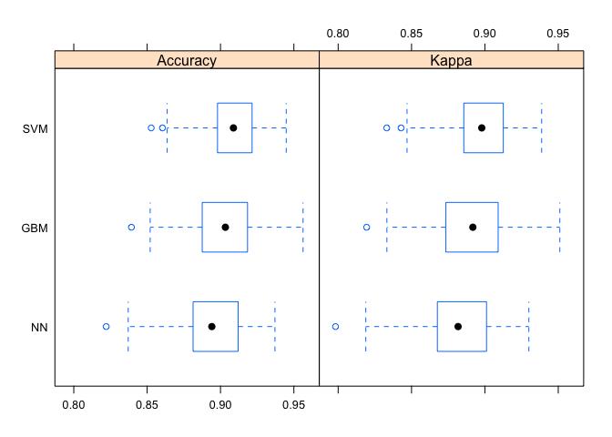

```r
# boxplots of results
bwplot(results)
```

> You can finetune the parameters for different models in Caret using tuneGrid.

### Additional metrics for evaluation

We can also consider other metrics to assess the performance of a model. This becomes particularly important when, for example, your your test set is imbalanced. In that scenario, evaluating the accuracy of a model might not be the best indication that your classifier works well. In fact, it may be biased by the over-represented class in your test set.

#### Kappa-score

Overall accuracy is a misleading statistic in case of unbalanced datasets. The kappa statistic overcomes thsi by taking the expected error into account.

#### ROC, Precision & Recall

Receiver-Operator Characteristic (ROC) Curves can be used to characterize the performance of our model in a binary classification setting.  
For binary classification, we might also be interested in precision and recall, i.e. a metric of our True Positive and True Negative rates.

```r
binary_preds = as.integer(y_pred_cv)-1
binary_true = as.integer(soyTest$Class)-1
precision <- sum(binary_preds & binary_true) / sum(binary_preds)
recall <- sum(binary_preds & binary_true) / sum(binary_true)
```

Precision tells us how often, when we predict a class ‘y’, do we get it correct.  
Recall tells us how often, out of all our ‘y’ instances, do we predict them correctly.

```r
#Precision
print(precision)
```

```
## [1] 0.1560284
```

```r
#Recall
print(recall)
```

```
## [1] 0.1405751
```

In case of multi-class classification, another metric that comes in handy is the F1-score. This is the harmonic mean of precision and recall. A high F1-score will tell you that you are quite precise and sensitive in your prediction of *all* classes.

```r
Fmeasure <- 2 * precision * recall / (precision + recall)
```

> In the models we fit for our multiclass problem, what was the Kappa statistic on our test set? What was the Accuracy?  
> Which model selection appraoch worked better, the bootstrapped SVM or the repeated 5-CV approach? How do we assess this (on the test set, or from the cross-validation results?)

## Discussion points

How good do you think a classifier will have to be to be clinically relevant? What level of specificity or sensitivity do you think is “good enough”? The author’s data set has half lymph-node positive and half negative. The incidence of lymph-node-positive breast cancer is about 33% at the time of diagnosis (according to [http://seer.cancer.gov/statfacts/html/breast.html]). How does that affect your opinion about the classifier?

### Take-home exercises (Restated from above)

Recall our 6-fold cross validation on the binary dataset.

**Exercise 1**: perform 100 runs of this CV before selecting a model to test! Add at least on model to the list of models, e.g., use genes with a p-val threshold < cutoff.

**Exercise 2**: Use AUC as a criteria to select a model based on the training data! Tip: extract the predicted probabilities from each method and use the roc function in ROCR.

# References

1: Varma S, Simon R: Bias in error estimation when using cross-validation for model selection. BMC Bioinformatics 2006, 7:91.

2: Statnikov A, Aliferis CF, Tsamardinos I, Hardin D, Levy S: A comprehensive evaluation of multicategory classification methods for microarray gene expression cancer diagnosis. Bioinformatics 2005, 21:631-643.